# Futures contracts - distribution generators, claims modeling and option pricing.

Project for the class Futures Contracts

Szymon Pawłowski

2023-02-25

# 1 Generator of pseudorandom numbers from uniform distribution by linear congruence method

## 1.1 Introduction

A pseudorandom number generator is called a procedure that generates random variables $U_1, U_2, ...$, such that:

1. $\forall_{i} \quad U_i \sim U(0,1)$,
2. the random variables $U_i$ are mutually independent.

With the second property being important because it implies the lack of correlation between all pairs of random variables and the fact that the random variable $U_i$ should not be predictable from the other random variables $U_1, ..., U_{i-1}$.

Such a pseudorandom number generator provides a finite sequence of numbers $u_1, u_2, ..., u_K$ on a unit interval, which mostly depend on the values of the generator parameters given by the user. Each such sequence represents a set of possible outcomes of independent variables $U_1, ..., U_K$, whereby small, relative to $K$, subsets of these sequences should be difficult to distinguish from realizations of a sequence of random variables from a uniform distribution.

An efficient generator returns values that are consistent with conditions (1) and (2) above. With a sufficiently large $K$, the fraction of generated values from a unit subinterval should be approximately equal to the length of that subinterval. Moreover, independence suggests that no pattern should be discernible in plotting the generated numbers.

## 1.2 Example generator

One of the example generators of pseudorandom numbers is the linear congruence generator. It can be expressed as follows
$$x_{i+1} = ax_i \ mod(m),$$
.
$$u_{i+1} = \frac{x_{i+1}}{m},$$
. In this case, the parameter $a$ is called *modulo*, while $m$ is called *modulo*. These are constants that determine the generated values when given an additional initialization value (*grain*) $x_0$. The grain is a user-specified integer with a value lying between $1$ and $m-1$.

We can write the operation $y \ mod(m)$ in another way
$$y \ mod(m) =
y - \lfloor \frac{y}{m} \rfloor \space m,$$
. where $\lfloor x \rfloor$ is the highest integer less than or equal to $x$. As you can see, the modulo operation will always return a value between $0$ and $m-1$. Hence, the values of $u_i$ returned by the generator will always lie between $0$ and $(m-1)/m$, and in particular, will lie on the unit interval.

Also note the term *full period*. A linear congruence generator reaches full period when it returns $m-1$ different values before any of them are repeated. In practice, it is expected to generate a huge number of different values (e.g. $10$ million) before any repetition occurs. In order to obtain such a result, **it is not enough** to set the $m$ parameter with a high value, since a poor choice of the $a$ parameter may result in the generation of numbers with short periods.

## 1.3 General rules for the construction of a pseudorandom number generator.

When constructing a pseudorandom number generator, consider the following aspects:

1. **Length of the period**, that is, the time to repeat the value. As a rule, the longer the period the better, so a generator is expected to produce as many different values as possible before repetition occurs. For a linear congruence generator with modulo $m$, the period is $m-1$. Such a generator reaches **full period** when the intervals between individual values of $u_i$ are of length $1/m$, so the higher the value of $m$, the more the generated values will approximate a uniform distribution.
2. **Reproducibility**, as it is often important to be able to reproduce the simulation using the same parameters and obtaining the same values. In the case of a linear congruence generator (or any other in general form), we get such an effect by setting the seed $x_0$.
3. **Speed**, since a pseudorandom number generator can be tasked with producing thousands or more values in a single simulation, care should be taken about the processing time of such a situation.
4. **Transparency**, that is, to produce the same sequences of generated values on all computer platforms. In the case of a linear congruence generator, there is sometimes a problem with different approaches to rounding values by which different results can be obtained.
5. **Randomness** is the most important aspect, which is the most difficult to ensure. In practice, two approaches are used to ensure randomness: theoretical properties and statistical tests.

## 1.4 Linear congruence generator

The linear congruence generator can be represented in general form
$$x_{i+1} = (ax_i + c) \ mod(m)$$
.
$$u_{i+1} = x_{i+1}/m$$
. Whereby the values of $a$, $m$ and $c$ must be integers. Moreover, there are certain conditions that ensure that the generator is fully periodic (that is, when from any seed $x_o$ the number of different values generated is $m-1$). Thus, when $c \neq 0$ one should make:

1. $c$ and $m$ are relatively prime, and so that their greatest common divisor is $1$;
2. every first number that divides $m$ also divides $a-1$;
3. the number $a-1$ is divisible by $4$ if $m$ is.

The above conditions imply the fact that if $m$ is some power of $2$ then the generator has a full period when $c$ is odd and $a=4n + 1$ for some integer $n$.

On the other hand, when $c=0$ and $m$ is a prime number, the full period is reached from any $x_0$ if:

1. $a^{m-1} - 1$ is not a multiple of $m$;
2. $a^j - 1$ is not a multiple of $m$ for $j = 1, ..., m-2$.

Such a number $a$ is called the **primary root** of the number $m$. It can be seen that in such a case, the sequence ${x_i}$ takes the form
$$x_0,\ ax_0,\ a^2x_0, \ a^3x_0,\ ..., \
(mod(m)).$$
.

Then, when $x_0 \neq 0$ then all the expressions of $x_i$ are also non-zero. Moreover, a generator with a parameter $c \neq 0$ is slower than one with a zero parameter, so it is customary to take a parameter $c=0$. It is then necessary to choose a prime number for $m$ to allow the construction of a generator with a full period, by simply finding the primes of $m$.

Below is an example function taking the form of a linear congruence generator, where the parameter $n$ determines the length of the vector of generated values, and the other parameters are analogous to those presented in the theory.

```r
lcgen <- function(n, m, a, c, x){

  gen <- vector(length = n)

  for (i in 1:n){
    x <- (a * x + c) %% m
    gen[i] <- x/m
  }

  return(gen)
}
```

Let’s check the performance of the implemented generator for certain small values by sticking to the given assumptions. To make it easier to check them we will implement additional functions, including:

1. a function that checks whether certain two numbers are relatively prime:

```r
gcd <- function(x,y) {
  r <- x%%y;
  return(ifelse(r, gcd(y, r), y))
}
```

2. a function that checks whether every first number dividing a certain number $x$, also divides $y$:

```r
prime_division <- function(x,y){
  is_prime <- function(n) n == 2L || all(n %% 2L:max(2,floor(sqrt(n))) != 0)

  div <- c(1:(y-1))
  divisors <- div[x %% div == 0]

  primes <- c()
  for (i in 1:length(divisors)){
    if (is_prime(divisors[i])==TRUE){
      if ((y-1) %% divisors[i] == 0){

        primes <- c(primes, TRUE)

      } else {
        print(divisors[i])
        primes <- c(primes, FALSE)
      }
    }
  }
  return(primes)

 1092 %% 2
}
```

3. function that checks divisibility by $4$:

```r
four_division <- function(x,y){
  if (((x %% 4 == 0) & ((y-1) %% 4 == 0)) | ((x %% 4 != 0) & ((y-1) %% 4 != 0))){
    return(TRUE)
  } else {
    return(FALSE)
  }
}
```

4. a function that checks whether a given number $x$ is not a multiple of a number $y$:

```r
multiplication <- function(x,y){
  if (y %% (x^(y-1)) != 0){
    return(TRUE)
  } else {
    return(FALSE)
  }
}
```

5. a function that checks whether a given number $x$ is not a multiple of a number $y$ for different values of exponents of powers:

```r
multi_multiplication <- function(x,y){
  info <- c()
  for (i in 1:(x-2)){
    if (y %% (x^i - 1) == 0){
      info <- c(info, FALSE)
    } else {
      info <- c(info, TRUE)
    }
  }
  return(info)
}
```

Using them, we construct a general function to check the validity of assumptions.

```r
check_assumptions <- function(m,a,c){
  if (c != 0){
    if (gcd(c,m) == 1){
      if (all(prime_division(m, a))==TRUE){
        if (four_division(m, a)==TRUE){
          return("Assumptions met!")
        }
        else{
          return("Error: the number m divisible by 4, but (a-1) is not!")
        }
      } else {
        return("Error: not every first number dividing m also divides a-1!")
      }
    } else {
      return("Error: the numbers c and m are not relatively prime!")
    }
  } else if (c == 0){
    if (multiplication(m, a)==TRUE){
      if (all(multi_multiplication(m,a))==TRUE){
        return("Assumptions met!")
      } else {
        return("Error: the number a^j - 1 is a multiple of m for some j!")
      }
    } else {
      return("Error: the number a^(m-1) is a multiple of m!")
    }
  } else {
    return("The case has not been served!")
  }
}
```

Having defined tools for checking the validity of assumptions, we can test the generator for certain values. Let’s start by generating $n=50$ values at a seed of $x_0=1$ with the assumed parameters
$$m = 53, \quad a = 20, \quad c = 0.$$
.

```r
check_assumptions(m=53, a=20, c=0)
```

```
## [1] "Assumptions met!"
```

We see that the assumed parameters meet the assumptions, so now let’s generate some numbers.

```r
lcgen(50, 53, 20, 0, 1)
```

```
##  [1] 0.37735849 0.54716981 0.94339623 0.86792453 0.35849057 0.16981132
##  [7] 0.39622642 0.92452830 0.49056604 0.81132075 0.22641509 0.52830189
## [13] 0.56603774 0.32075472 0.41509434 0.30188679 0.03773585 0.75471698
## [19] 0.09433962 0.88679245 0.73584906 0.71698113 0.33962264 0.79245283
## [25] 0.84905660 0.98113208 0.62264151 0.45283019 0.05660377 0.13207547
## [31] 0.64150943 0.83018868 0.60377358 0.07547170 0.50943396 0.18867925
## [37] 0.77358491 0.47169811 0.43396226 0.67924528 0.58490566 0.69811321
## [43] 0.96226415 0.24528302 0.90566038 0.11320755 0.26415094 0.28301887
## [49] 0.66037736 0.20754717
```

Indeed, we have obtained generated values from the unit interval that do not repeat. According to the theory presented, changing $n$ to $n=53$ should already show us the first repetition, as the assumptions of full periodicity have been met.

```r
lcgen(53, 53, 20, 0, 1)
```

```
##  [1] 0.37735849 0.54716981 0.94339623 0.86792453 0.35849057 0.16981132
##  [7] 0.39622642 0.92452830 0.49056604 0.81132075 0.22641509 0.52830189
## [13] 0.56603774 0.32075472 0.41509434 0.30188679 0.03773585 0.75471698
## [19] 0.09433962 0.88679245 0.73584906 0.71698113 0.33962264 0.79245283
## [25] 0.84905660 0.98113208 0.62264151 0.45283019 0.05660377 0.13207547
## [31] 0.64150943 0.83018868 0.60377358 0.07547170 0.50943396 0.18867925
## [37] 0.77358491 0.47169811 0.43396226 0.67924528 0.58490566 0.69811321
## [43] 0.96226415 0.24528302 0.90566038 0.11320755 0.26415094 0.28301887
## [49] 0.66037736 0.20754717 0.15094340 0.01886792 0.37735849
```

As you can see, the last value is already the next iteration of the whole period. Let’s check the operation for even smaller values by choosing
$$m=7, \quad a=2, \quad
c=0.$$
.

```r
check_assumptions(m=7, a=2, c=0)
```

```
## [1] "Assumptions met!"
```

```r
lcgen(50, 7, 2, 0, 1)
```

```
##  [1] 0.2857143 0.5714286 0.1428571 0.2857143 0.5714286 0.1428571 0.2857143
##  [8] 0.5714286 0.1428571 0.2857143 0.5714286 0.1428571 0.2857143 0.5714286
## [15] 0.1428571 0.2857143 0.5714286 0.1428571 0.2857143 0.5714286 0.1428571
## [22] 0.2857143 0.5714286 0.1428571 0.2857143 0.5714286 0.1428571 0.2857143
## [29] 0.5714286 0.1428571 0.2857143 0.5714286 0.1428571 0.2857143 0.5714286
## [36] 0.1428571 0.2857143 0.5714286 0.1428571 0.2857143 0.5714286 0.1428571
## [43] 0.2857143 0.5714286 0.1428571 0.2857143 0.5714286 0.1428571 0.2857143
## [50] 0.5714286
```

With such parameter values, of course, the period has a much shorter length, so the number of repetitions at $50$ generated values will be larger. Now let’s check the situation for larger parameter values and $c \neq 0$ and consider the following.
$$m = 86436, \quad a = 1093, \quad c =
18257.$$
.

```r
check_assumptions(m=86436, a=1093, c=18257)
```

```
## [1] "Assumptions met!"
```

```r
lcgen(50, 86436, 1093, 18257, 1)
```

```
##  [1] 0.2238650562 0.8957263177 0.2400851497 0.6242884909 0.5585404230
##  [6] 0.6959021704 0.8322921005 0.9064857235 0.0001156925 0.3376718034
## [11] 0.2865009950 0.3568073488 0.2016520894 0.6169535842 0.5414873432
## [16] 0.0568860197 0.3876394095 0.9010944514 0.1074552270 0.6597829608
## [21] 0.3539960202 0.1288699153 0.0660372993 0.3899879680 0.4680688602
## [26] 0.8104840576 0.0702947846 0.0434194086 0.6686334398 0.0275695312
## [31] 0.3447174788 0.9874242214 0.4658938405 0.4331875607 0.6852237494
## [36] 0.1607779166 0.9414827155 0.2518279421 0.4591605350 0.0736845759
## [41] 0.7484612893 0.2794090425 0.6053033458 0.8077768522 0.1113193577
## [46] 0.8832778009 0.6338562636 0.0161159702 0.8259752881 0.0022097274
```

Again, let’s change the parameters to
$$m
= 2^{11} +1, \quad a = 64, \quad c=73.$$
.

```r
check_assumptions(m=(2^11+1), a=64, c=73)
```

```
## [1] "Assumptions met!"
```

```r
lcgen(50, (2^11 + 1), 64, 73, 1)
```

```
##  [1] 0.0668618838 0.3147877013 0.1820400195 0.6861883846 0.9516837482
##  [6] 0.9433870181 0.4123962909 0.4289897511 0.4909712055 0.4577842850
## [11] 0.3338213763 0.4001952172 0.6481210347 0.5153733529 0.0195217179
## [16] 0.2850170815 0.2767203514 0.7457296242 0.7623230844 0.8243045388
## [21] 0.7911176184 0.6671547096 0.7335285505 0.9814543680 0.8487066862
## [26] 0.3528550512 0.6183504148 0.6100536847 0.0790629575 0.0956564178
## [31] 0.1576378721 0.1244509517 0.0004880429 0.0668618838 0.3147877013
## [36] 0.1820400195 0.6861883846 0.9516837482 0.9433870181 0.4123962909
## [41] 0.4289897511 0.4909712055 0.4577842850 0.3338213763 0.4001952172
## [46] 0.6481210347 0.5153733529 0.0195217179 0.2850170815 0.2767203514
```

```r
check_assumptions(m=8, a=2, c=1)
```

```
## [1] "Error: the number m divisible by 4, but (a-1) is not!"
```

```r
lcgen(50, 8, 2, 1, 1)
```

```
##  [1] 0.375 0.875 0.875 0.875 0.875 0.875 0.875 0.875 0.875 0.875 0.875 0.875
## [13] 0.875 0.875 0.875 0.875 0.875 0.875 0.875 0.875 0.875 0.875 0.875 0.875
## [25] 0.875 0.875 0.875 0.875 0.875 0.875 0.875 0.875 0.875 0.875 0.875 0.875
## [37] 0.875 0.875 0.875 0.875 0.875 0.875 0.875 0.875 0.875 0.875 0.875 0.875
## [49] 0.875 0.875
```

The assumption that $a-1$ is divisible by 4 when $m$ is divisible has not been met. We can see that only two different values were generated, where in this case we would expect seven. Let’s change, then, and substitute $a=4$ to make it divisible by 4.

```r
check_assumptions(m=8, a=4, c=1)
```

```
## [1] 2
```

```
## [1] "Error: not every first number dividing m also divides a-1!"
```

```r
lcgen(50, 8, 4, 1, 1)
```

```
##  [1] 0.625 0.625 0.625 0.625 0.625 0.625 0.625 0.625 0.625 0.625 0.625 0.625
## [13] 0.625 0.625 0.625 0.625 0.625 0.625 0.625 0.625 0.625 0.625 0.625 0.625
## [25] 0.625 0.625 0.625 0.625 0.625 0.625 0.625 0.625 0.625 0.625 0.625 0.625
## [37] 0.625 0.625 0.625 0.625 0.625 0.625 0.625 0.625 0.625 0.625 0.625 0.625
## [49] 0.625 0.625
```

```r
check_assumptions(m=9, a=4, c=3)
```

```
## [1] "Error: the numbers c and m are not relatively prime!"
```

```r
lcgen(50, 9, 4, 1, 3)
```

```
##  [1] 0.4444444 0.8888889 0.6666667 0.7777778 0.2222222 0.0000000 0.1111111
##  [8] 0.5555556 0.3333333 0.4444444 0.8888889 0.6666667 0.7777778 0.2222222
## [15] 0.0000000 0.1111111 0.5555556 0.3333333 0.4444444 0.8888889 0.6666667
## [22] 0.7777778 0.2222222 0.0000000 0.1111111 0.5555556 0.3333333 0.4444444
## [29] 0.8888889 0.6666667 0.7777778 0.2222222 0.0000000 0.1111111 0.5555556
## [36] 0.3333333 0.4444444 0.8888889 0.6666667 0.7777778 0.2222222 0.0000000
## [43] 0.1111111 0.5555556 0.3333333 0.4444444 0.8888889 0.6666667 0.7777778
## [50] 0.2222222
```

```r
check_assumptions(m=9, a=8, c=0)
```

```
## [1] "Error: the number a^j - 1 is a multiple of m for some j!"
```

```r
lcgen(50, 9, 8, 0, 3)
```

```
##  [1] 0.6666667 0.3333333 0.6666667 0.3333333 0.6666667 0.3333333 0.6666667
##  [8] 0.3333333 0.6666667 0.3333333 0.6666667 0.3333333 0.6666667 0.3333333
## [15] 0.6666667 0.3333333 0.6666667 0.3333333 0.6666667 0.3333333 0.6666667
## [22] 0.3333333 0.6666667 0.3333333 0.6666667 0.3333333 0.6666667 0.3333333
## [29] 0.6666667 0.3333333 0.6666667 0.3333333 0.6666667 0.3333333 0.6666667
## [36] 0.3333333 0.6666667 0.3333333 0.6666667 0.3333333 0.6666667 0.3333333
## [43] 0.6666667 0.3333333 0.6666667 0.3333333 0.6666667 0.3333333 0.6666667
## [50] 0.3333333
```

We got a sequence without a full period without any pseudo-randomness (the generated values are actually a repeating sequence of of numbers $(2/3, 1/3)$). Let’s still base the values $m=2$, $a=1$.

```r
check_assumptions(m=2, a=1, c=0)
```

```
## [1] "Error: the number a^(m-1) is a multiple of m!"
```

```r
lcgen(50, 2, 1, 0, 3)
```

```
##  [1] 0.5 0.5 0.5 0.5 0.5 0.5 0.5 0.5 0.5 0.5 0.5 0.5 0.5 0.5 0.5 0.5 0.5 0.5 0.5
## [20] 0.5 0.5 0.5 0.5 0.5 0.5 0.5 0.5 0.5 0.5 0.5 0.5 0.5 0.5 0.5 0.5 0.5 0.5 0.5
## [39] 0.5 0.5 0.5 0.5 0.5 0.5 0.5 0.5 0.5 0.5 0.5 0.5
```

In such a case, we have a fixed sequence consisting of a single number. The presented erroneous examples perfectly reflect the relevance of the assumptions made, in the first part of the work, to obtain a correct linear congruence pseudorandom generator.

## 1.5 The problem of exceeding the range of integers

The examples considered above do not exceed the integer range. The situation changes somewhat when we want to use really high parameter values, for example, a large multiplier $a$. Then the generator can be constructed in a slightly different form, representing $a$ as $a=2^\alpha a_1 + a_2$, where $a_1, a_2 < 2^\alpha$, and then writing the
$$ax_i \ mod(m) = (a_1(2^{alpha} x_i \
mod(m)) + a_2 x_i \ mod(m)) \ mod(m).$$

In this way, we are able to prevent integer overruns. Writing using integer arithmetic is often faster than using floating-point arithmetic. However, in order to avoid overflow, the linear conguration generator in integer arithmetic must be limited to an extremely small value modulo $m=2^{15} - 1$.

## 1.6 Visualization and evaluation

If the random variables $U_1, U_2, U_3, ...$ are independent and come from the unitary distribution $U(0,1)$, then the $(U_1, U_2)$ random vector will also come from the unitary distribution described on the unit square, while the $(U_1, U_2, U_3)$ random vector will come from the unitary distribution described on the unit cube, and so on. Therefore, one way to compare the results of a pseudorandom generator among themselves is to map them onto a $[0,1]^d$ grid, and then see to what extent they fill the area uniformly. Ideally, no pattern would be discernible with visualization, but such does not exist because always, with sufficiently close inspection, a pattern can always be seen. However, we hope that at the desired size, it will be as inconspicuous as possible. In addition, a histogram is useful to check whether the distribution of points really resembles a uniform distribution. Let’s prepare a function for plotting such a visualization:

```r
# Display Results
plotting <- function(u){
  m <- length(u)
  par(mfrow=c(1,2), pty="s")
  hist(u, breaks=10, col="wheat", main=NULL)
  abline(h=m/10, lty="dashed")
  u1 = u[1:(m-1)]; u2 = u[2:m]
  plot (u1, u2, pch=19)
  par(mfrow=c(1,1), pty="m")
  mtext(paste("Generated results for the length vector",m))
}
```

Let’s check for a generator with the first parameters.

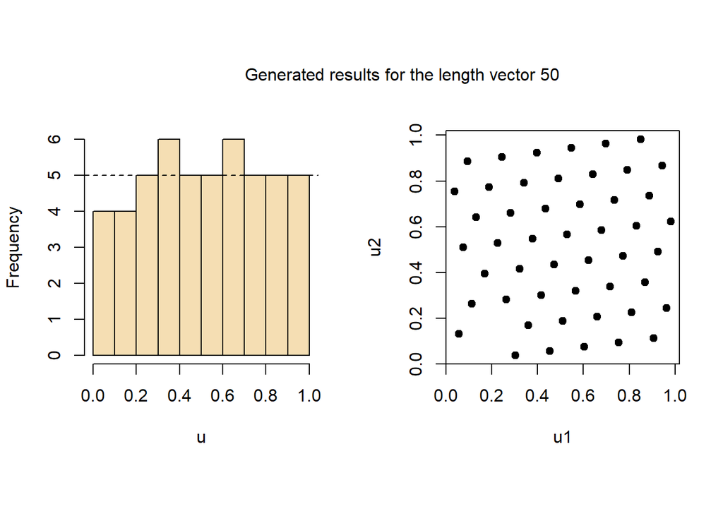

```r
u <- lcgen(50, 53, 20, 0, 1)
plotting(u)
```

We can easily see the pattern, so let’s see if the length of the generated $n$ vector changes the situation.

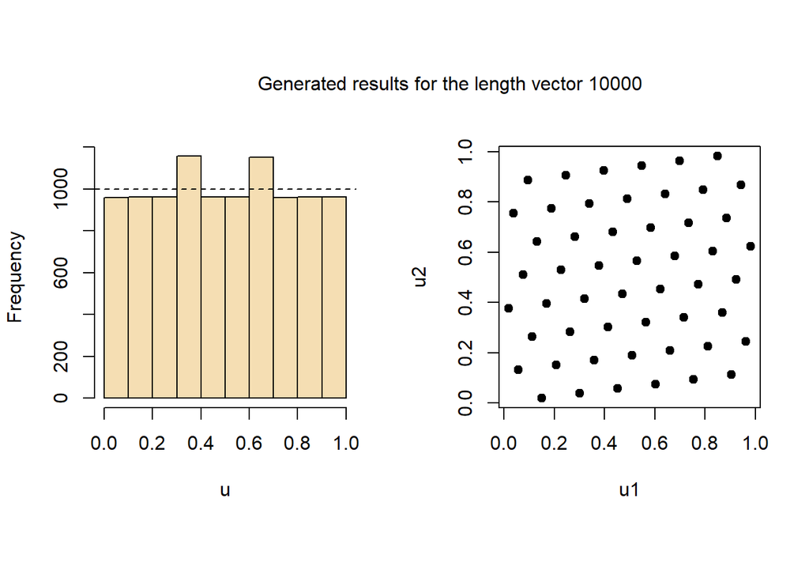

```r
u <- lcgen(10000, 53, 20, 0, 1)
plotting(u)
```

Some values have “leveled off” to a uniform distribution, but others have “broken through.” In addition, the pattern deepens. The selected parameters evidently give rather poor results in terms of randomness. Let’s change their selection and so check the second of the above-mentioned parameter examples.

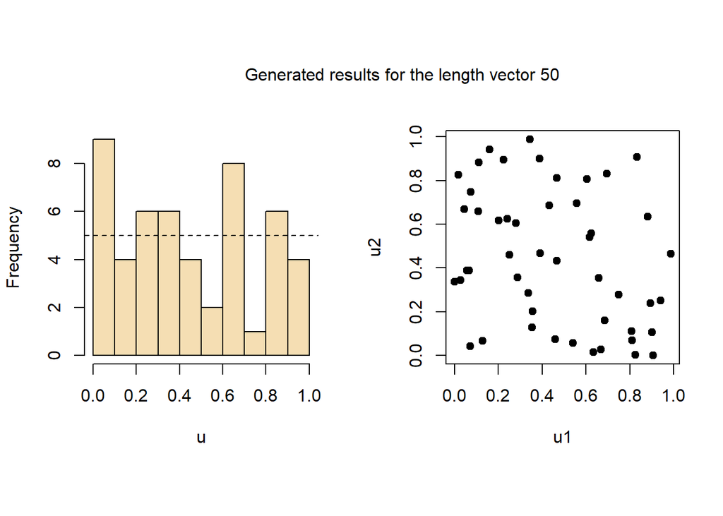

```r
u <- lcgen(50, 86436, 1093, 18257, 1)
plotting(u)
```

With $50$ of values generated, the distribution approximates a uniform distribution quite poorly, but some randomness is evident when mapping the values. Let’s increase the number of samples to $n=1000$.

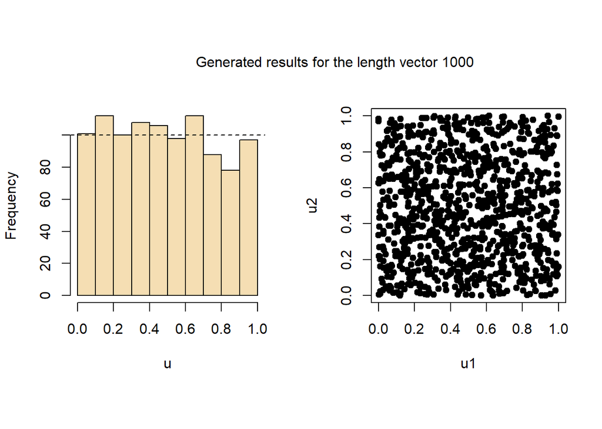

```r
u <- lcgen(1000, 86436, 1093, 18257, 1)
plotting(u)
```

Immediately you can see a significant improvement, the distribution looks more and more like a uniform distribution, and the mapping begins to fill the unit square without a clear pattern. Let’s go a step further and increase the number of samples again, this time to $n=10000$.

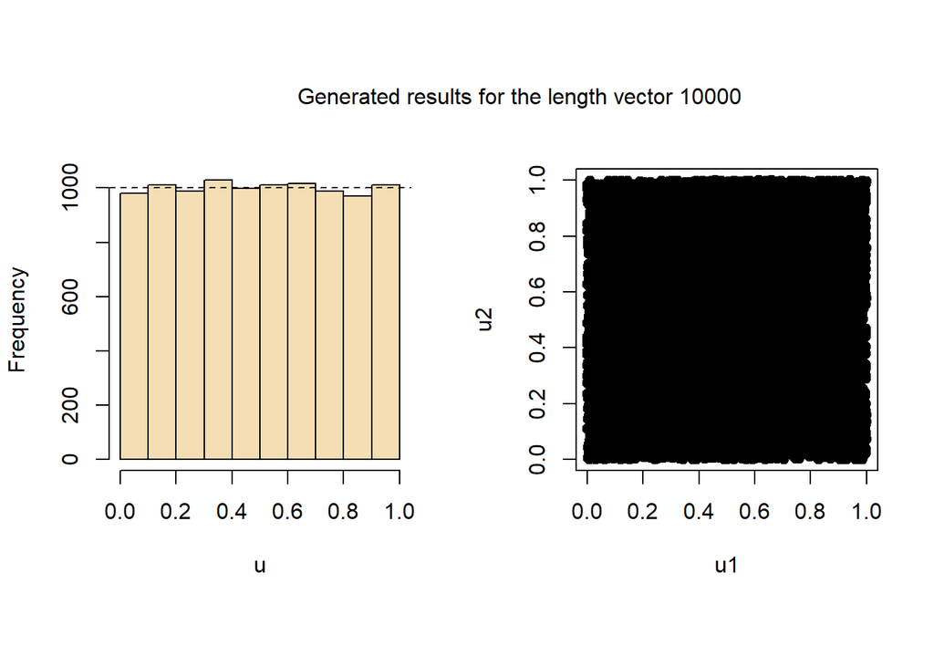

```r
u <- lcgen(10000, 86436, 1093, 18257, 1)
plotting(u)
```

The example perfectly shows how the generated values came very close to a uniform distribution and filled almost the entire square. Unlike the first visualizations, here we can talk about well-chosen parameters, which show the accurate pseudorandomness of the generator. However, let’s take an even slightly smaller sample of $n=100$ to see some correlations with respect to the parameters.

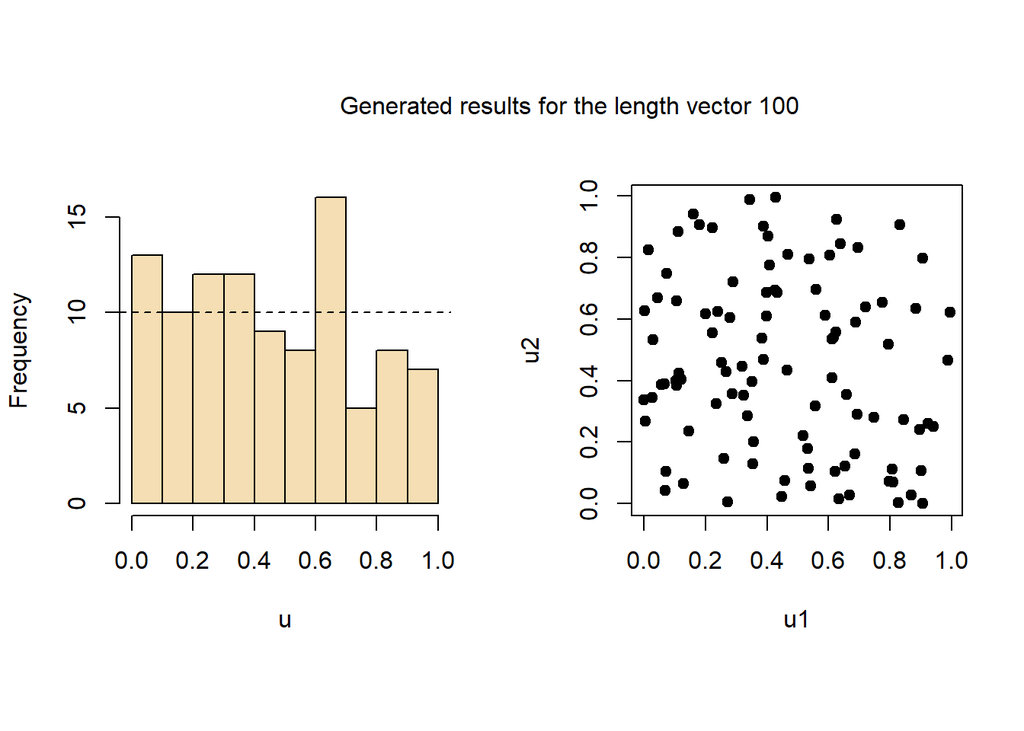

```r
u <- lcgen(100, 86436, 1093, 18257, 1)
plotting(u)
```

Now we will change the random seed $x_0$ to the value $x_0 = 142$.

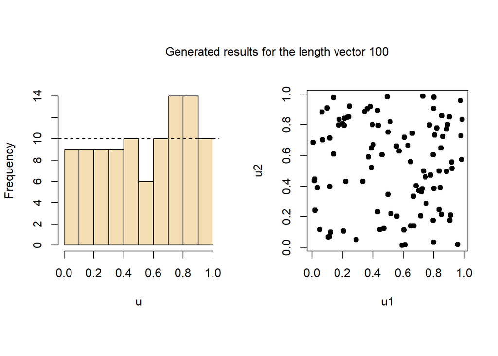

```r
u <- lcgen(100, 86436, 1093, 18257, 142)
plotting(u)
```

We can notice on the mapping of the generated points that they are distributed differently. This is a natural consequence, since the grain initializes our starting point and guarantees the reproducibility of the results. As a final step, let’s compare the above generated results with those obtained through the linear congruence generator available in the library. To do this, we will use the *fBasics* library and the *runif.lcg* function. We will start by generating a value for the sample $n=100$.

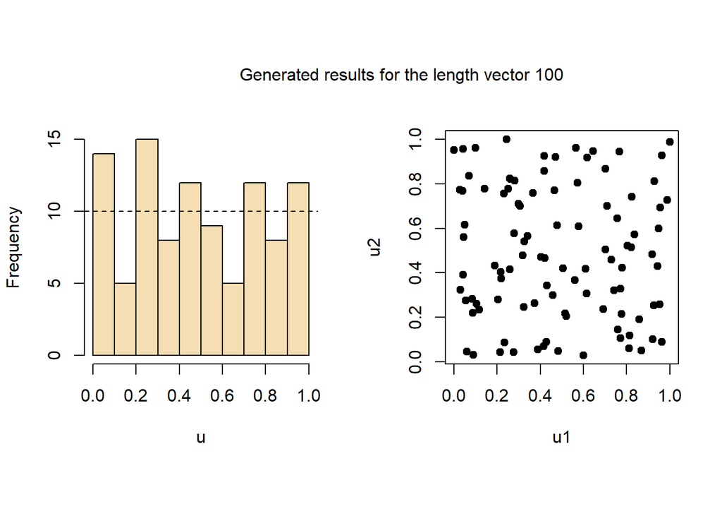

```r
library(fBasics)
set.lcgseed(142)
u <- runif.lcg(n=100, min=0, max=1)
plotting(u)
```

The results are similar, the distribution resembling the unitary distribution, and the mapping without imposing patterns. So let’s see which one gets faster visual convergence to the uniform distribution and unit square filling.

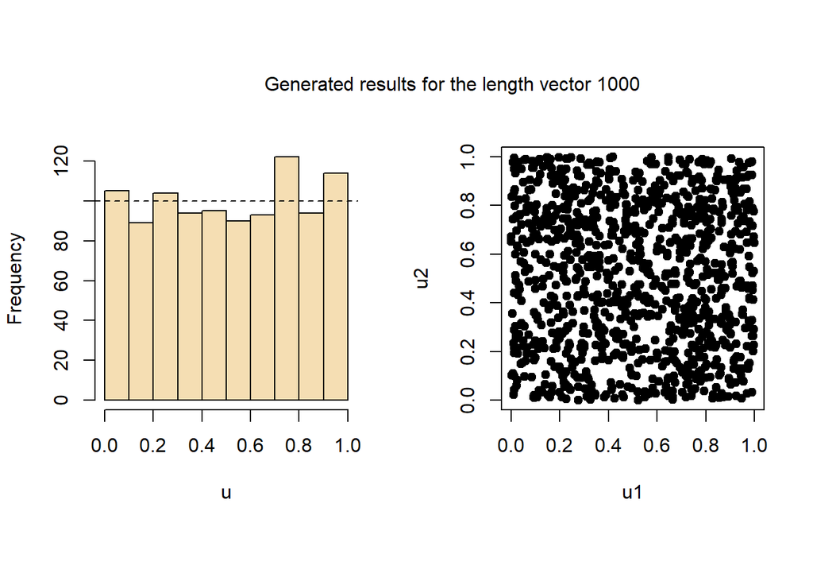

```r
u <- runif.lcg(n=1000, min=0, max=1)
plotting(u)
```

Still the results are comparable, so let’s take $n=$10000.

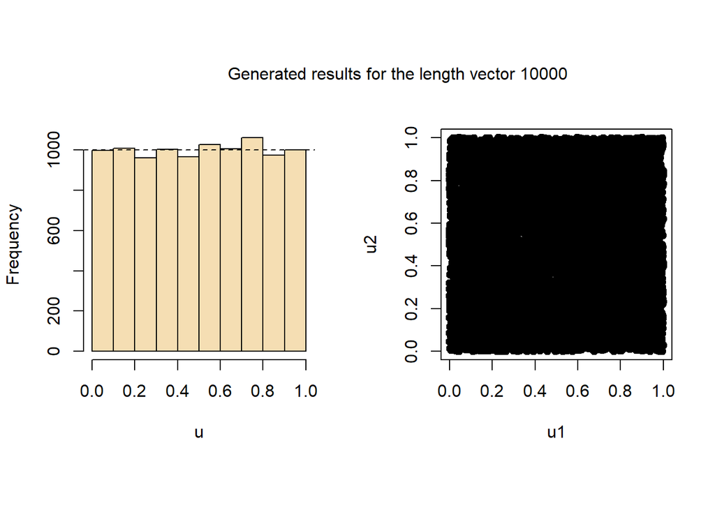

```r
u <- runif.lcg(n=10000, min=0, max=1)
plotting(u)
```

And in this case, no change, the generator from the library at this sample size also almost completely fills the area of the square and its distribution is strongly similar to the uniform distribution. This is, of course, the expected conclusion, since both approaches use a linear congruence generator. Possible differences may arise, for example, from the timing of the generation of pseudorandom numbers due to at least the arithmetic used, as mentioned earlier. In addition, the linear congruence algorithm can be adapted in several ways depending on the assumptions made, where some may be faster. However, with the generator already implemented in the library, we have no need to initialize the parameters, which, as we have seen, can cause the generated numbers to be erroneous and not come from a uniform distribution.

## 1.7 Summary

In the first part, the general idea of a pseudorandom number generator was presented, along with the conditions for obtaining an effective generator. Then an example generator, which was a linear congruence generator, was given, along with the algorithm for obtaining it. Later, the general principles of pseudorandom number generator design were discussed with important concepts such as period length, reproducibility, speed, portability and randomness. The next step was a discussion of the linear congruence generator. Its general form was given, as well as the assumptions it must meet in order to obtain from it reliable results of generated pseudorandom numbers. Based on this, the generator function and functions for checking the assumptions were created and folded into one. They proceeded to check the written generator on examples, those that met the assumptions, as well as those that did not. The results obtained were briefly interpreted and a final conclusion was drawn about the relevance of assumptions during construction. The problem of exceeding the integer range was also briefly discussed. The final step was the visualization of the results and their evaluation. Two previously used examples were cited from which relevant conclusions were drawn. Correct results were also compared with those obtained with the help of a generator built in one of the libraries and described. There are many ways to create a correct generator, but it is always necessary to check the assumptions and, above all, meet them.

# 2 Implementation of a pseudorandom number generator from given distributions

## 2.1 Introduction

Having created a pseudorandom number generator, we assume the availability of an ideal sequence of random numbers, that is, we consider a sequence of independent random variables $U_1, U_2, ...$, where each of them satisfies
$$P(U_i \leq u) = \begin{cases}
0, & u <0 \\
u, & 0 \leq u <1 \\
1, & u >1.
\end{cases}$$
. so it comes from the uniform distribution $U([0,1])$. Often we want to obtain a sequence of numbers generated from a distribution other than the uniform distribution, for this purpose, transformations are mostly used on samples from the uniform distribution to transform them so that they come from another desired distribution. One such method is the inverse transformation.

When implementing algorithms to generate numbers from different distributions, we will use a pseudorandom number generator from the uniform distribution created earlier, as well as a function that controls assumptions. At the same time, for the values of $m$, $a$, $c$, $x$ we will take the following.
$$m = 2^{31} -1,
\quad a = 16807, \quad c=24, \quad x=1$$
. as the valid values of the generator, values
$$m = 2^{11} +1, \quad
a = 64, \quad c=73, \quad x=1$$
. as relatively correct values, and
$$m = 8, \quad a=2, \quad c=1,\quad
x=1$$
. as incorrect values.

## 2.2 Inverse transformation method

Suppose we want to sample from the distribution, so we want to generate a random variable $X$ with a property such that $P(X \leq x) = F(x)$ for each $x$. Then the inverse transformation method is as follows.
$$X = F^{-1}(U), \quad U \sim U([0,1]),$$
. where $F^{-1}$ is the inverse of the distribution of $F$ and is correctly determined when $F$ is strictly increasing. To get around the problem where $F$ is flattened (because there the inverse function will not be correctly defined), the inverse function is defined by
$$F^{-1}(u) = \inf\{x: \quad F(x) \geq
u\}.$$

Note, however, that if $F$ is constant on some interval $[a,b]$, and $X$ has a distribution of $F$ then
$$P(a
< X \leq b) = F(b) - F(a) = 0$$
. so such areas have zero probability for a random variable to occur there. If $F$ has a continuous derivative (density) then it is strictly increasing wherever the density is non-zero. To show that the inverse transformation method generates samples from the distribution of $F$, we check the distribution of $X$, which returns
$$P(X\leq x) = P(F^{-1}(U)\leq x) = P(U\leq
F(x)) = F(x)$$
Moreover, this method can be interpreted as the fact that the percentile into which $X$ “falls” has a uniform distribution. The inverse transformation method selects a uniformly distributed percentile, which it then maps to the corresponding value of the random variable.

## 2.3 Exponential distribution

```r
exp_rand <- function(N,theta,m=valid[1], a=valid[2], c=valid[3], x=valid[4], mode="self"){
  if (check_assumptions(m,a,c) == 'Assumptions met!' & mode=="self"){
    U <- lcgen(N,m,a,c,x)
    X <- -1/theta*log(U)

  }
  else if (check_assumptions(m,a,c) != 'Assumptions met!' & mode=="self"){
    print("Values for assumptions incorrect!")
    U <- lcgen(N,m,a,c,x)
    X <- -1/theta*log(U)

  }
  else {
    U <- runif(N)
    X <- -1/theta*log(U)
  }
  return(X)
}
```

We will also create a function that generates a histogram along with a density function and returns basic descriptive statistics, namely mean, median, variance and standard deviation, as well as theoretical values.

```r
plot_and_check <- function(X, theta, title){
  hist(X, prob=TRUE, col="grey", main=title)
  lines(density(X), col="blue", lwd=2)

  mean = 1/theta
  median = log(2)/theta
  var = 1/(theta^2)
  std = sqrt(var)

  mean_x = mean(X)
  median_x = median(X)
  var_x = var(X)
  std_x = sqrt(var_x)

  t <- c(mean, median, var, std)
  p <- c(mean_x, median_x, var_x, std_x)

  print("Theoretical values:")
  print(paste("Average: ", mean, ", Median: ", median))
  print(paste("Variance: ", var, ", STD: ", std))
  print("Wartości wygenerowane:")
  print(paste("Average: ", mean_x, ", Median: ", median_x))
  print(paste("Variance: ", var_x, ", STD: ", std_x))
  }
```

Let’s check for invalid values

```r
exp <- exp_rand(N=1000, theta=1, m=nonvalid[1], a=nonvalid[2], c=nonvalid[3], x=nonvalid[4])
```

```
## [1] "Values for assumptions incorrect!"
```

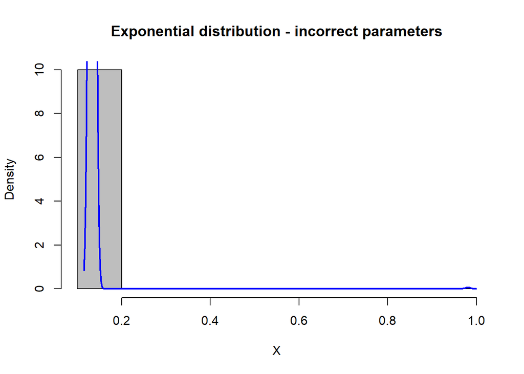

```
## [1] "Theoretical values:"
## [1] "Average:  1 , Median:  0.693147180559945"
## [1] "Variance:  1 , STD:  1"
## [1] "Wartości wygenerowane:"
## [1] "Average:  0.13437869048491 , Median:  0.133531392624523"
## [1] "Variance:  0.000717913664216733 , STD:  0.0267939109541092"
```

```r
plot_and_check(exp, theta=1, "Exponential distribution - incorrect parameters")
```

One can easily see absurd results in the absence of fulfilled assumptions for the generator of numbers from a uniform distribution. Moreover, the descriptive statistics are significantly different from the theoretical ones. Let’s check the generator for relatively correct values.

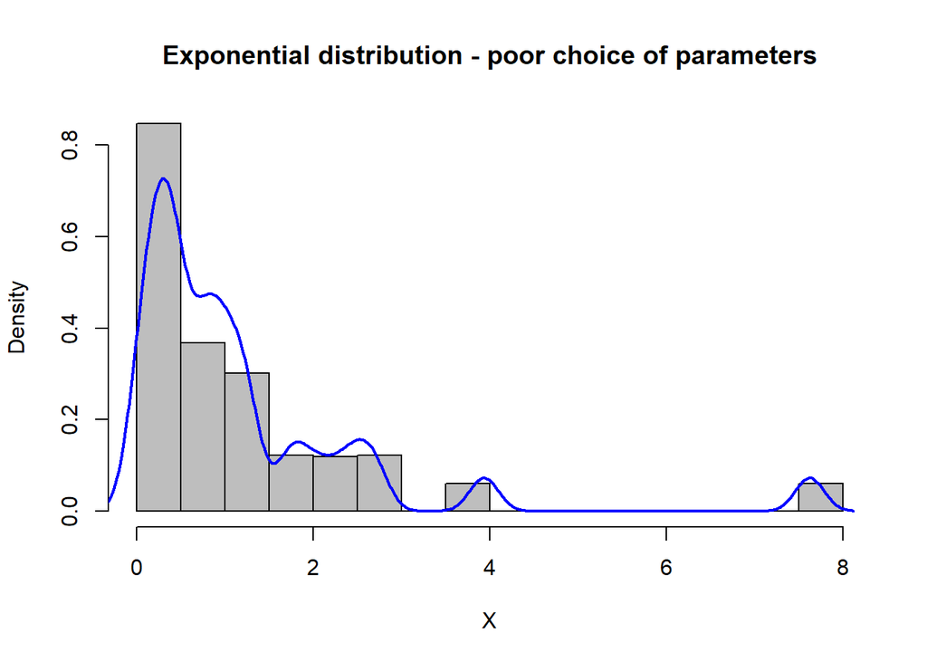

```
## [1] "Theoretical values:"
## [1] "Average:  1 , Median:  0.693147180559945"
## [1] "Variance:  1 , STD:  1"
## [1] "Wartości wygenerowane:"
## [1] "Average:  1.185472049113 , Median:  0.781357199232675"
## [1] "Variance:  2.08071716697754 , STD:  1.44246912167212"
```

```r
exp <- exp_rand(N=1000, theta=1, m=badvalid[1], a=badvalid[2], c=badvalid[3], x=badvalid[4])
plot_and_check(exp, theta=1, title= "Exponential distribution - poor choice of parameters")
```

There is an improvement in performance, but there are undesirable “hills.” Moreover, the descriptive statistics, although more similar, still deviate quite a bit from the theoretical values. Let’s check for the correct values.

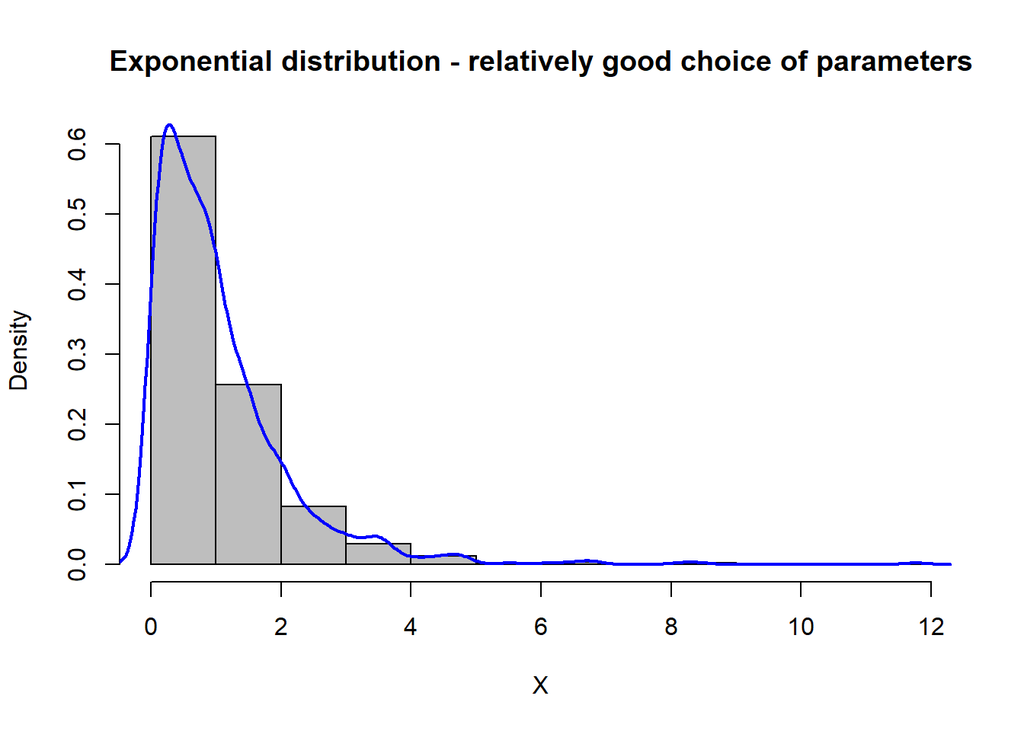

```
## [1] "Theoretical values:"
## [1] "Average:  1 , Median:  0.693147180559945"
## [1] "Variance:  1 , STD:  1"
## [1] "Wartości wygenerowane:"
## [1] "Average:  1.04619757800968 , Median:  0.788099951887279"
## [1] "Variance:  1.16269013278082 , STD:  1.07828110100327"
```

```r
exp <- exp_rand(N=1000, theta=1, m=valid[1], a=valid[2], c=valid[3], x=valid[4])
plot_and_check(exp, theta=1, title = "Exponential distribution - relatively good choice of parameters")
```

We can now see that the “hills” have been almost completely eliminated and our distribution resembles an exponential distribution. In addition, the statistics generated are strongly close to the theoretical statistics. Possible stronger deviations are seen with the variance. Let’s compare it with the distribution generated with the built-in generator.

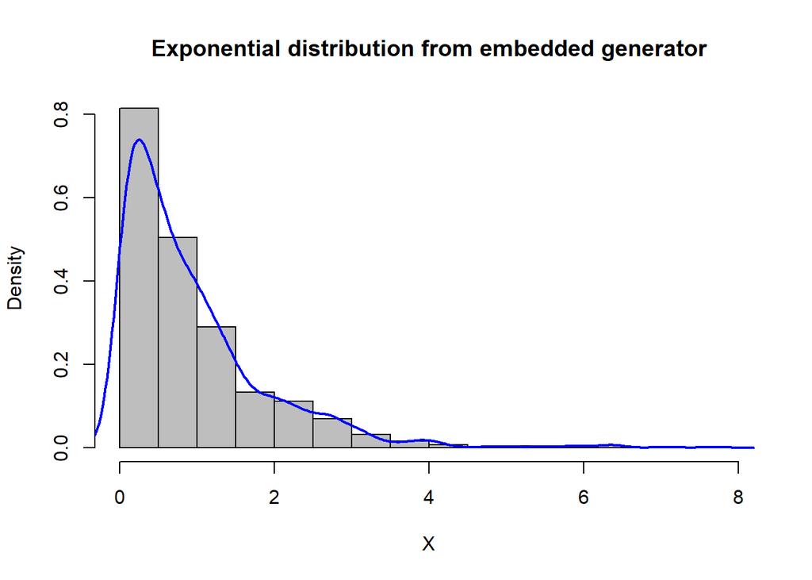

```
## [1] "Theoretical values:"
## [1] "Average:  1 , Median:  0.693147180559945"
## [1] "Variance:  1 , STD:  1"
## [1] "Wartości wygenerowane:"
## [1] "Average:  0.94774191876402 , Median:  0.655436681117862"
## [1] "Variance:  0.958569723453949 , STD:  0.979065740108369"
```

```r
exp <- rexp(1000, rate=1)
plot_and_check(exp, theta=1, title="Exponential distribution from embedded generator")
```

We can see that the built-in generator performs similarly. Also, the statistics generated are slightly deviated from the theoretical ones. However, it should be noted that properly selected parameters for the linear congruence generator are crucial. In the case of selecting such that do not meet the assumptions or with too little “randomness”, our results will not be satisfactory, so we should pay attention to selecting such parameters for which the obtained randomness will be sufficient to generate a pseudo-random sample coming from another family of distributions. Let’s check the results for other parameters $\theta$, including $\theta = 3/2$.

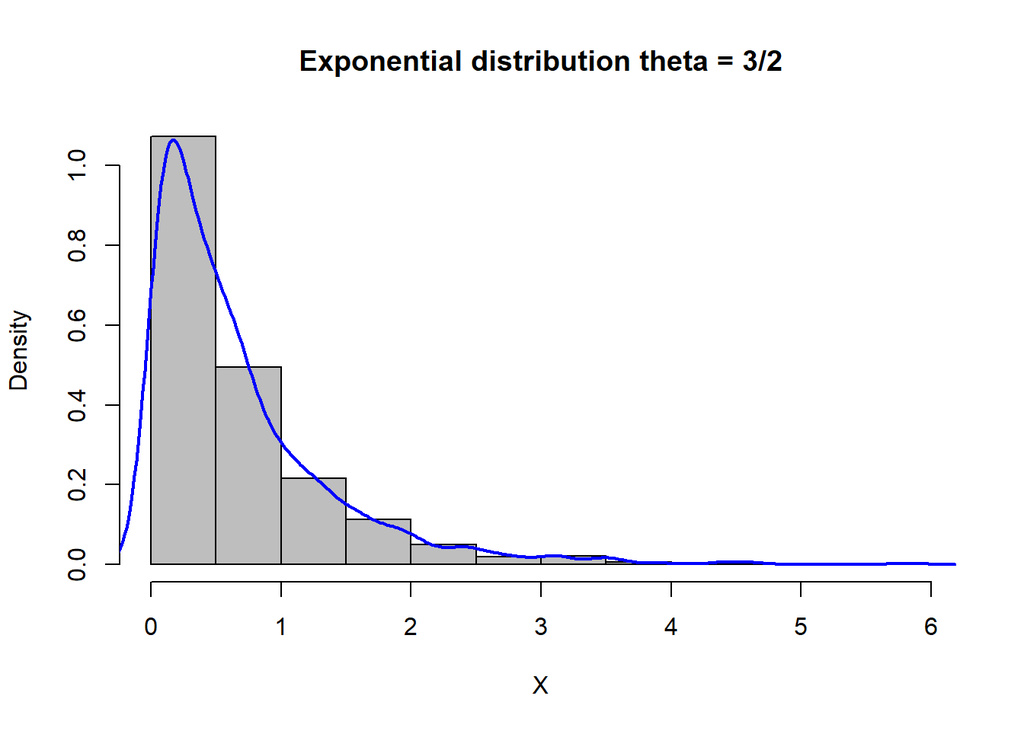

```
## [1] "Theoretical values:"
## [1] "Average:  0.666666666666667 , Median:  0.462098120373297"
## [1] "Variance:  0.444444444444444 , STD:  0.666666666666667"
## [1] "Wartości wygenerowane:"
## [1] "Average:  0.669505862052829 , Median:  0.44970102358055"
## [1] "Variance:  0.500691734689855 , STD:  0.707595742419254"
```

```r
exp6 <- exp_rand(N=1000, theta=3/2, mode="implemented")
plot_and_check(exp6, theta=3/2, title = "Exponential distribution theta = 3/2")
```

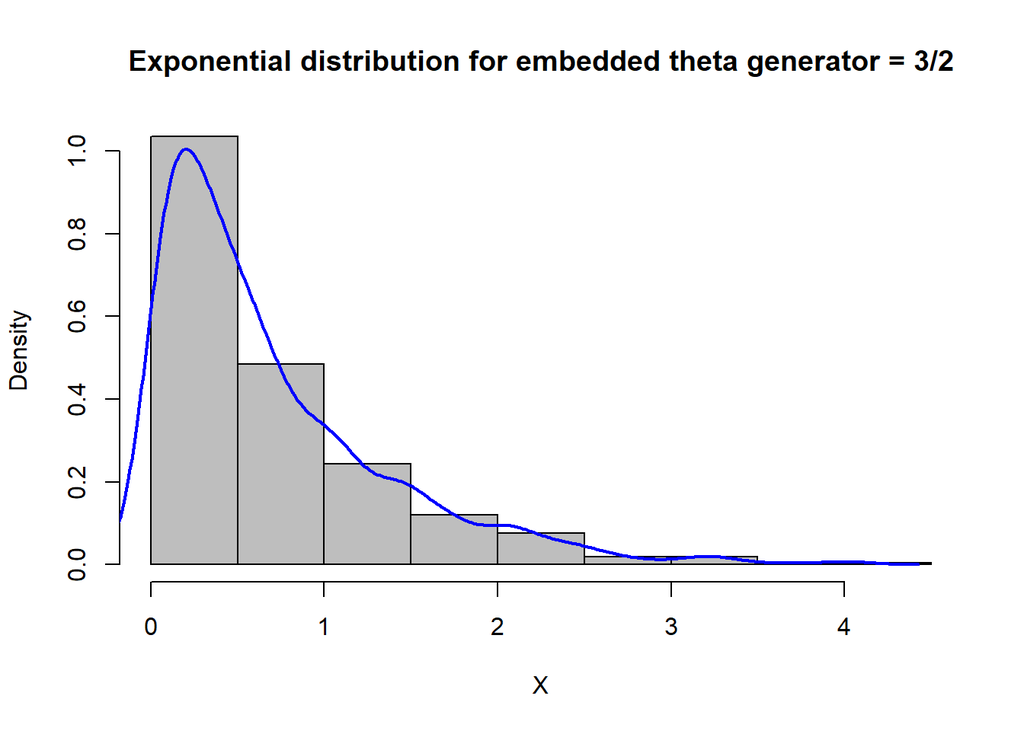

```
## [1] "Theoretical values:"
## [1] "Average:  0.666666666666667 , Median:  0.462098120373297"
## [1] "Variance:  0.444444444444444 , STD:  0.666666666666667"
## [1] "Wartości wygenerowane:"
## [1] "Average:  0.690387830238647 , Median:  0.479910690991352"
## [1] "Variance:  0.443585200059061 , STD:  0.666021921605483"
```

```r
exp7 <- rexp(1000, rate=3/2)
plot_and_check(exp7, theta=3/2, title= "Exponential distribution for embedded theta generator = 3/2")
```

## 2.4 Weibull distribution

The Weibull distribution with parameters $\theta$ and $k$ has the distribution
$$F(x) = 1-e^{-(x\theta)^k}, \quad x\geq
0.$$
. Depending on the choice of $k$, we can actually get an exponential distribution ($k=1$), or a Rayleigh distribution ($k=2$) and even a normal distribution (for large $k$). By inverting the distributions, we will get the ability to create an algorithm to generate samples from the Weibull distribution through the uniform distribution
$$X =
|\theta|(-log{(1-U)})^{1/k},$$
. but since $1-U$ has the same distribution as $U$ we can write as
$$X = |\theta|(-log{(U)})^{1/k},$$
. We will create the generator using the previously created pseudorandom number generator from the uniform distribution.

```r
weibull_rand <- function(N,theta,k,m=valid[1], a=valid[2], c=valid[3], x=valid[4], mode="self"){
  if (check_assumptions(m,a,c) == 'Assumptions met!' & mode=="self"){
    U <- lcgen(N,m,a,c,x)
    X <- abs(theta)*(-log(U))^(1/k)

  }
  else if (check_assumptions(m,a,c) != 'Assumptions met!' & mode=="self"){
    print("Values for assumptions incorrect!")
    U <- lcgen(N,m,a,c,x)
    X <- abs(theta)*(-log(U))^(1/k)

  }
  else {
    U <- runif(N)
    X <- abs(theta)*(-log(U))^(1/k)

  }
  return(X)
}
```

We will also create a function that generates a histogram along with a density function and returns basic descriptive statistics, namely mean, median, variance and standard deviation, as well as theoretical values.

```r
plot_and_check_weibull <- function(X, theta, k, title){
  hist(X, prob=TRUE, col="grey", main=title)
  lines(density(X), col="blue", lwd=2)

  mean = theta*gamma(1+1/k)
  median = theta*log(2)^(1/k)
  var = theta^2 * gamma(1+2/k) - (theta*gamma(1+1/k))^2
  std = sqrt(var)

  mean_x = mean(X)
  median_x = median(X)
  var_x = var(X)
  std_x = sqrt(var_x)

  t <- c(mean, median, var, std)
  p <- c(mean_x, median_x, var_x, std_x)

  print("Theoretical values:")
  print(paste("Average: ", mean, ", Median: ", median))
  print(paste("Variance: ", var, ", STD: ", std))
  print("Generated values:")
  print(paste("Average: ", mean_x, ", Median: ", median_x))
  print(paste("Variance: ", var_x, ", STD: ", std_x))

  }
```

Let’s check for invalid values

```r
weib <- weibull_rand(N=1000, theta=1, k=1, m=nonvalid[1], a=nonvalid[2], c=nonvalid[3], x=nonvalid[4])
```

```
## [1] "Values for assumptions incorrect!"
```

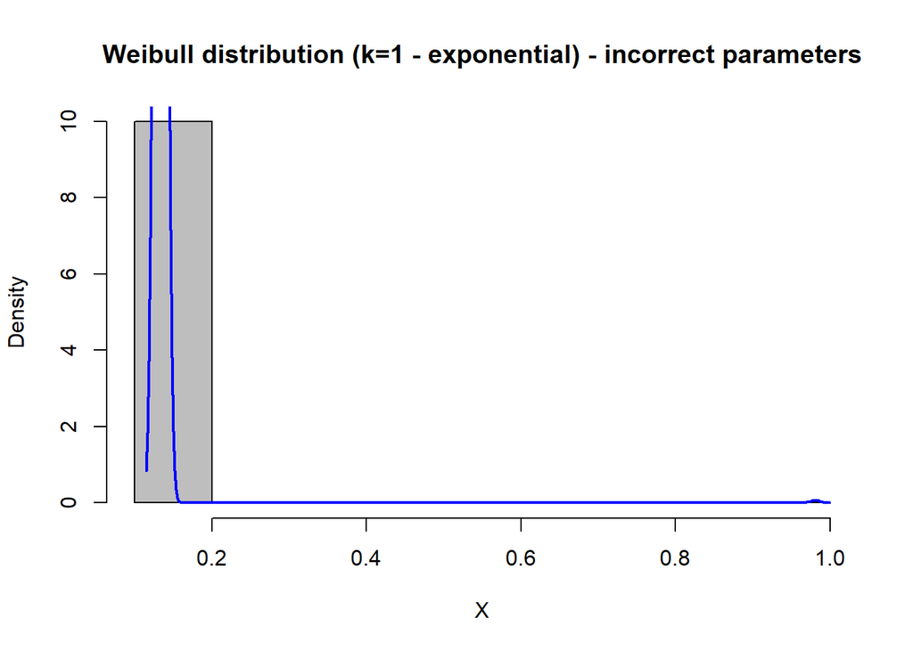

```
## [1] "Theoretical values:"
## [1] "Average:  1 , Median:  0.693147180559945"
## [1] "Variance:  1 , STD:  1"
## [1] "Generated values:"
## [1] "Average:  0.13437869048491 , Median:  0.133531392624523"
## [1] "Variance:  0.000717913664216733 , STD:  0.0267939109541092"
```

```r
plot_and_check_weibull(weib, theta=1, k =1, title = "Weibull distribution (k=1 - exponential) - incorrect parameters")
```

You can easily see identical results to the Exponential distribution generator. The results obtained are also incorrect, and the statistics differ significantly. Let’s check the generator for relatively correct values.

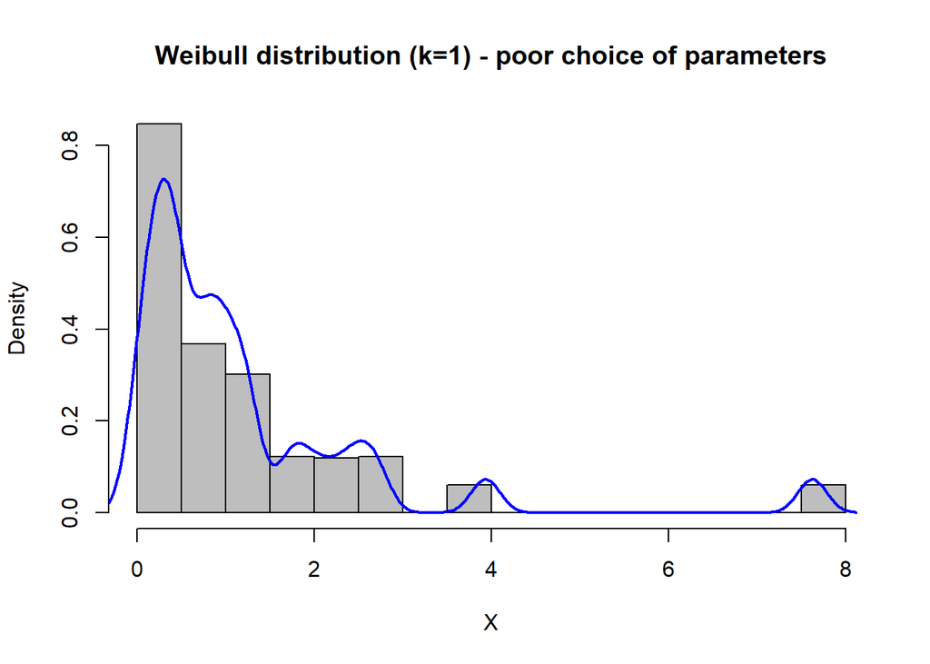

```
## [1] "Theoretical values:"
## [1] "Average:  1 , Median:  0.693147180559945"
## [1] "Variance:  1 , STD:  1"
## [1] "Generated values:"
## [1] "Average:  1.185472049113 , Median:  0.781357199232675"
## [1] "Variance:  2.08071716697754 , STD:  1.44246912167212"
```

```r
weib <- weibull_rand(N=1000, theta=1, k =1, m=badvalid[1], a=badvalid[2], c=badvalid[3], x=badvalid[4])
plot_and_check_weibull(weib, theta=1, k=1, title= "Weibull distribution (k=1) - poor choice of parameters")
```

Again we can see the improve of the results but also with the “hills”. Let’s check for the correct values.

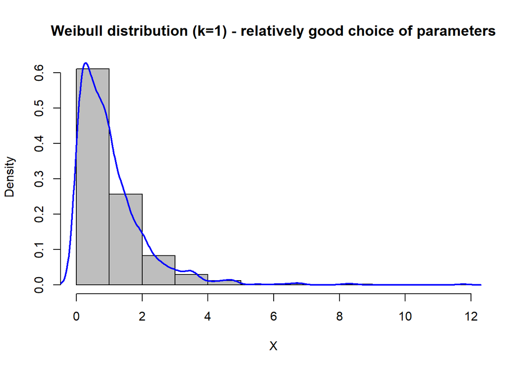

```
## [1] "Theoretical values:"
## [1] "Average:  1 , Median:  0.693147180559945"
## [1] "Variance:  1 , STD:  1"
## [1] "Generated values:"
## [1] "Average:  1.04619757800968 , Median:  0.788099951887279"
## [1] "Variance:  1.16269013278082 , STD:  1.07828110100327"
```

```r
weib <- weibull_rand(N=1000, theta=1, k=1, m=valid[1], a=valid[2], c=valid[3], x=valid[4])
plot_and_check_weibull(weib, theta=1, k=1, title = "Weibull distribution (k=1) - relatively good choice of parameters")
```

We now see that the “hills” have been almost completely eliminated and our distribution resembles an exponential distribution (this is how it should come out at $k=1$). In addition, the statistics generated are strongly close to the theoretical statistics. We have already shown, both in the previous report and in this one with two examples, that proper selection of parameters for the linear congruence generator is essential to obtain satisfactory results - after all, they are what we base our subsequent generators on. In order to reduce the amount of text, we will omit testing on the wrong parameters in the following section due to the fact that their relevance has already been shown. Moreover, as mentioned in the previous report, when using a pseudorandom number generator from a uniform distribution, there is no need to select the appropriate parameters. Taking this into account, as well as the fact that we could probably select even better parameter values for our generator from the uniform distribution, we will continue to use the built-in generator for numbers from the uniform distribution. This approach will provide the most reliable representation of pseudo-randomness. Specifically for such a case, a “mode” parameter was implemented in each function to allow the selection of the generator. Let’s now check the values for the other parameters $k$ and $\theta$ and compare it with the distribution generated using the built-in generator.

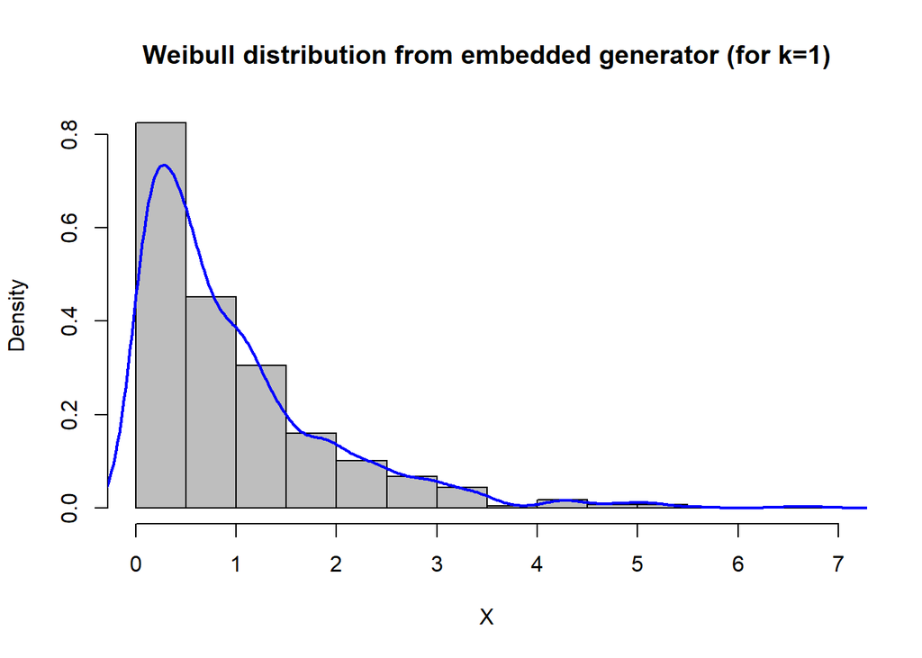

```
## [1] "Theoretical values:"
## [1] "Average:  1 , Median:  0.693147180559945"
## [1] "Variance:  1 , STD:  1"
## [1] "Generated values:"
## [1] "Average:  0.968606906799039 , Median:  0.654271356403889"
## [1] "Variance:  0.948516909831984 , STD:  0.973918328111749"
```

```r
exp <- rweibull(1000, scale=1, shape=1)
plot_and_check_weibull(exp, theta=1, k=1,title="Weibull distribution from embedded generator (for k=1)")
```

We can see that the built-in generator performs similarly. Also, the statistics generated in a small way are deviated from the theoretical ones. Quite like the exponential distribution, this is important information, as it tells us the correct way to build the Weibull distribution generator - with this choice of parameter $k$ exactly the exponential distribution is desired. Let’s check the results for other parameters $\theta$ and $k$, including $\theta = 2$ and $k=2$ (Rayleigh distribution).

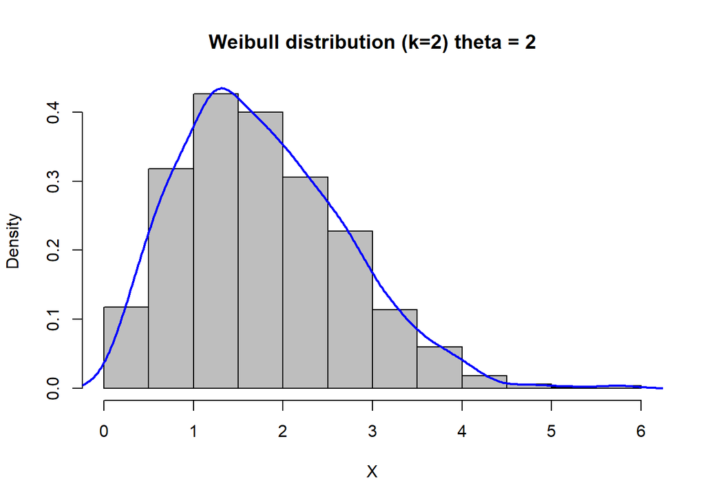

```
## [1] "Theoretical values:"
## [1] "Average:  1.77245385090552 , Median:  1.6651092223154"
## [1] "Variance:  0.858407346410206 , STD:  0.926502750352208"
## [1] "Generated values:"
## [1] "Average:  1.7783432940518 , Median:  1.66972711278443"
## [1] "Variance:  0.854137421634019 , STD:  0.924195553783948"
```

```r
weib <- weibull_rand(N=1000, theta=2, k=2, mode="implemented")
plot_and_check_weibull(weib, theta=2, k=2, title = "Weibull distribution (k=2) theta = 2")
```

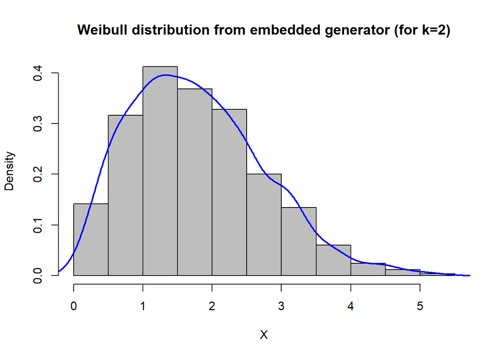

```
## [1] "Theoretical values:"
## [1] "Average:  1.77245385090552 , Median:  1.6651092223154"
## [1] "Variance:  0.858407346410206 , STD:  0.926502750352208"
## [1] "Generated values:"
## [1] "Average:  1.7778355098962 , Median:  1.67147255017567"
## [1] "Variance:  0.913083209962043 , STD:  0.955553876012255"
```

```r
w2 <- rweibull(1000, scale=2, shape=2)
plot_and_check_weibull(w2, theta=2, k=2,title="Weibull distribution from embedded generator (for k=2)")
```

We received again very similar results. Visualization of the distributions (using the built-in generator and our own) shows how close they are. However, it is the statistics that are key and most reliable here, and the values are not far from the theoretical values. It can be deduced that the generator we created performs quite well compared to the built-in generator.

## 2.5 The distribution of the arcus sine

By inverting the distribution, we will obtain the ability to create an algorithm to generate samples from the arcsine distribution through the uniform distribution
$$X =
\sin^2(U\pi/2),$$
. but since we can use the property $2\sin^2(t)=1-\cos(2t)$ then.
$$X = \frac{1}{2} -
\frac{1}{2}\cos(U\pi),$$
. We will create the generator, again, using the previously created pseudorandom number generator from the uniform distribution.

```r
arcsin_rand <- function(N,m=valid[1], a=valid[2], c=valid[3], x=valid[4], mode="self"){
  if (check_assumptions(m,a,c) == 'Assumptions met!' & mode=="self"){
    U <- lcgen(N,m,a,c,x)
    X <- 1/2 - 1/2*cos(U*pi)
  }
  else if (check_assumptions(m,a,c) != 'Assumptions met!' & mode=="self"){
    print("Values for assumptions incorrect!")
    U <- lcgen(N,m,a,c,x)
    X <- 1/2 - 1/2*cos(U*pi)
  } else {
    U <- runif(N)
    X <- 1/2 - 1/2*cos(U*pi)

  }
  return(X)
}
```

We will also create, once again for the new distribution, a function that generates a histogram along with a density function and returns basic descriptive statistics, namely the mean, median, variance and standard deviation, as well as theoretical values.

```r
plot_and_check_arcsin <- function(X, theta, k, title){
  hist(X, prob=TRUE, col="grey", main=title)
  lines(density(X), col="blue", lwd=2)

  mean = 1/2
  median = 1/2
  var = 1/8
  std = sqrt(var)

  mean_x = mean(X)
  median_x = median(X)
  var_x = var(X)
  std_x = sqrt(var_x)

  t <- c(mean, median, var, std)
  p <- c(mean_x, median_x, var_x, std_x)

  print("Theoretical values:")
  print(paste("Average: ", mean, ", Median: ", median))
  print(paste("Variance: ", var, ", STD: ", std))
  print("Generated values:")
  print(paste("Average: ", mean_x, ", Median: ", median_x))
  print(paste("Variance: ", var_x, ", STD: ", std_x))

  }
```

Let’s generate a certain sample and compare the values of the statistics to the theoretical values.

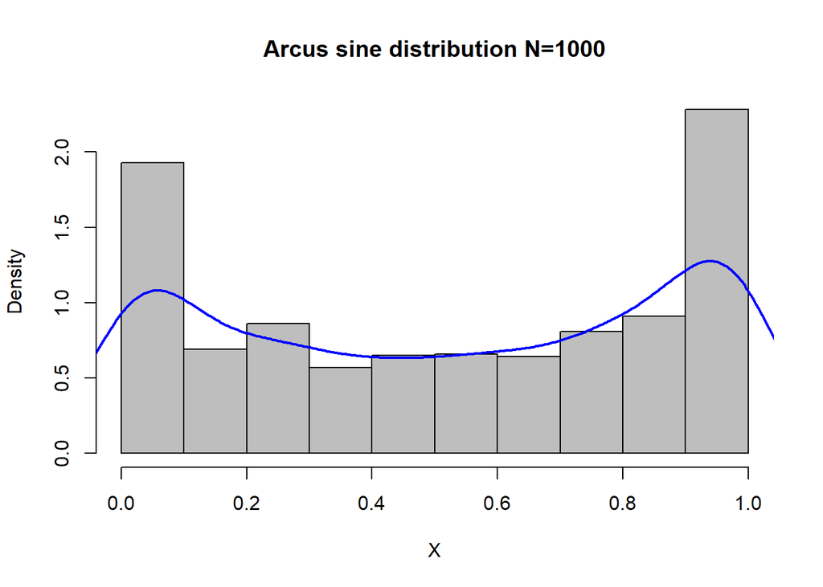

```
## [1] "Theoretical values:"
## [1] "Average:  0.5 , Median:  0.5"
## [1] "Variance:  0.125 , STD:  0.353553390593274"
## [1] "Generated values:"
## [1] "Average:  0.523013904133724 , Median:  0.551992915340564"
## [1] "Variance:  0.125131191853764 , STD:  0.353738875236755"
```

```r
arc <- arcsin_rand(N=1000, mode="implemented")
plot_and_check_arcsin(arc, title = "Arcus sine distribution N=1000")
```

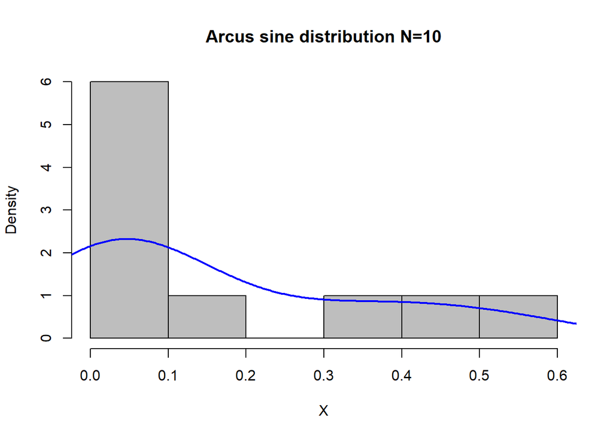

```
## [1] "Theoretical values:"
## [1] "Average:  0.5 , Median:  0.5"
## [1] "Variance:  0.125 , STD:  0.353553390593274"
## [1] "Generated values:"
## [1] "Average:  0.163922389135865 , Median:  0.0616864936628501"
## [1] "Variance:  0.0374766661433461 , STD:  0.193588910176554"
```

```r
arc <- arcsin_rand(N=10, mode="implemented")
plot_and_check_arcsin(arc, title = "Arcus sine distribution N=10")
```

Now we already see significant deviations, but this is expected. Let’s check for a larger sample $N=10000$.

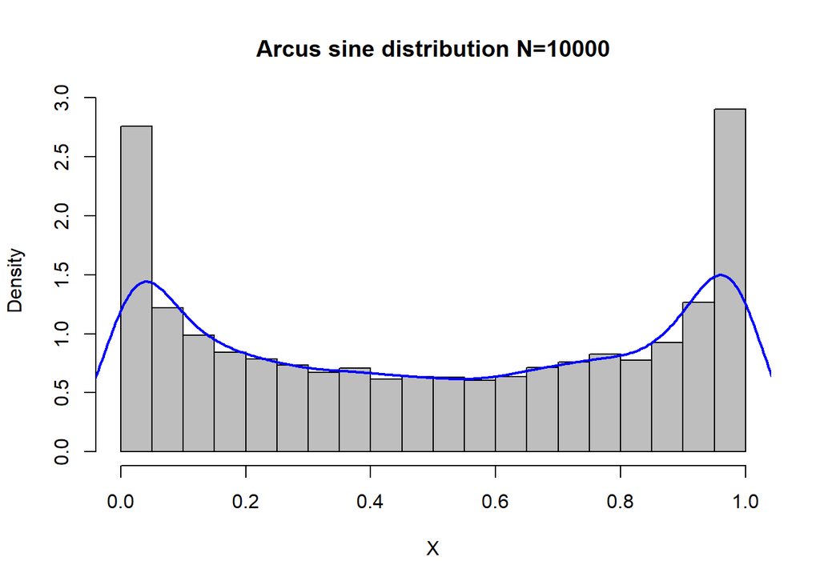

```
## [1] "Theoretical values:"
## [1] "Average:  0.5 , Median:  0.5"
## [1] "Variance:  0.125 , STD:  0.353553390593274"
## [1] "Generated values:"
## [1] "Average:  0.502935888059619 , Median:  0.503667703970204"
## [1] "Variance:  0.124526192399231 , STD:  0.352882689288142"
```

```r
arc <- arcsin_rand(N=10000, mode="implemented")
plot_and_check_arcsin(arc, title = "Arcus sine distribution N=10000")
```

The values are almost of the same value. The generator achieves great results, but I have not been able to find a built-in generator of this distribution, to which one could additionally collate the results obtained. So let’s move on to another generator of numbers from the normal distribution.

## 2.6 Normal distribution

We will use two approaches to generate numbers from the normal distribution. The first will be implemented using the double exponential. To do this, let’s note that the density of the double exponential distribution on a simple $(-\infty, +\infty)$ is
$$g(x) = \frac{e^{-|x|}}{2}$$
. while the density of the normal distribution is equal to
$$f(x) = e^{-x^2/2}/{\sqrt{2}}$$
. The ratio is as follows
$$\frac{f(x)}{g(x)} =
\sqrt{\frac{2}{\pi}}e^{\frac{1}{2}x^2 + |x|} = \sqrt{\frac{2e}{\pi}}.
\approx 1.3155 \equiv c.$$
. Hence, the density of the normal distribution is dominated by the scaled density of the double exponential distribution $cg(x)$. We are able to generate a sample from the double exponential distribution by using a previously created generator and drawing a certain set of values from it and then randomly determining the sign. In turn, the sample rejection test $u > f(x)/cg(x)$ can be implemented as follows.
$$u > e^{\frac{1}{2}x^2 + |x| -\frac{1}{2}} =
e^{-\frac{1}{2}(|x| - 1)^2}.$$
In the context of the symmetry of the two densities $f$ and $g$, it is important to generate a positive sample and determine the sign only if it is accepted. In this case, the absolute value is unnecessary in the rejection test. In the end, the algorithm presents itself as follows:

```r
normal_double <- function(N,m=valid[1], a=valid[2], c=valid[3], x=valid[4], mode="self"){
  if ((check_assumptions(m,a,c) == 'Assumptions met!' & mode == "self") | mode != "self"){
    X <- c()
    i <- 0
    while(length(X) < N){
      i <- i+1
      if (mode == "self"){
        U <- lcgen(4,m,a,c,x+i)
      } else {
        U <- runif(4)
      }
      U1 <- U[2]
      U2 <- U[3]
      U3 <- U[4]

      tmp <- -log(U1)
      if (U2 > exp(-0.5*(tmp-1)^2)){
        next
      }else if (U3 <= 0.5){
        tmp <- -tmp
      }

      X <- append(X,tmp)
    }
    return(X)
    }else{
      print("Values for assumptions incorrect!")
      return(0)
    }
  }
```

In addition, we create a function to plot the results obtained, along with a comparison of the descriptive statistics obtained from the sample with the theoretical statistics for a normal distribution.

```r
plot_and_check_normal <- function(X, title){
  hist(X, prob=TRUE, col="grey", main=title)
  lines(density(X), col="blue", lwd=2)

  mean = 0
  median = 0
  var = 1
  std = 1

  mean_x = mean(X)
  median_x = median(X)
  var_x = var(X)
  std_x = sqrt(var_x)

  t <- c(mean, median, var, std)
  p <- c(mean_x, median_x, var_x, std_x)

  print("Theoretical values:")
  print(paste("Average: ", mean, ", Median: ", median))
  print(paste("Variance: ", var, ", STD: ", std))
  print("Generated values:")
  print(paste("Average: ", mean_x, ", Median: ", median_x))
  print(paste("Variance: ", var_x, ", STD: ", std_x))

  }
```

Let’s check our generator.

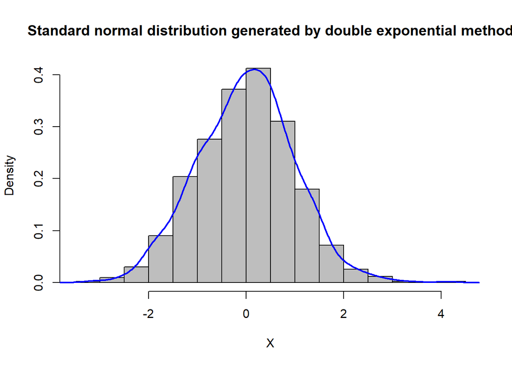

```
## [1] "Theoretical values:"
## [1] "Average:  0 , Median:  0"
## [1] "Variance:  1 , STD:  1"
## [1] "Generated values:"
## [1] "Average:  -0.0023144727609043 , Median:  0.0114150603753748"
## [1] "Variance:  0.977044215565997 , STD:  0.988455469692994"
```

```r
nor <- normal_double(N=1000, mode="implemented")
plot_and_check_normal(nor, title = "Standard normal distribution generated by double exponential method")
```

We can see that it indeed resembles a standard normal distribution. Moreover, the obtained descriptive statistics do not deviate much from the theoretical statistics. Let’s compare it further to the embedded generator.

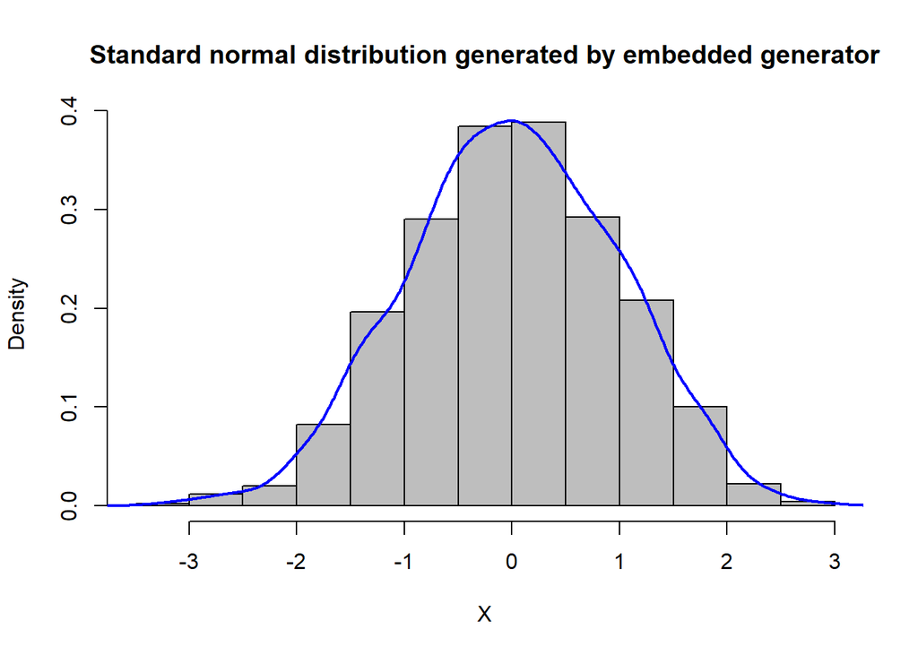

```
## [1] "Theoretical values:"
## [1] "Average:  0 , Median:  0"
## [1] "Variance:  1 , STD:  1"
## [1] "Generated values:"
## [1] "Average:  0.0077960578037843 , Median:  0.0169212423026347"
## [1] "Variance:  0.952814892393451 , STD:  0.976122375726246"
```

```r
nor <- rnorm(n=1000)
plot_and_check_normal(nor, title = "Standard normal distribution generated by embedded generator")
```

Interestingly, with a sample size of $N=1000$, our double exponential generator achieved even closer values of descriptive statistics (theoretical statistics) than the built-in generator. One could conclude that it is a more accurate generator. But let’s move on to the second method which is the Box-Muller method. This method is one of the simpler to implement (but not the fastest). It generates a sample from a two-dimensional standard normal distribution, where each of the individual dimensions is, of course, from a one-dimensional normal distribution. This algorithm is based on the following two properties of the two-dimensional normal distribution. Specifically, if $Z \sim N(0, I_2)$ then. 1. $R = Z_{1}^{2} + Z_{2}^{2}$ has an exponential distribution with mean $2$, i.e.
$$P(R
\leq x) = 1 - e^{-x/2}.$$
.

2. given $R$, the point $(Z_1,Z_2)$ has a uniform distribution on a circle of radius $\sqrt{R}$ and centered at the origin of the coordinate system.

So in order to generate a two-dimensional standard normal distribution $(Z_1, Z_2)$, we first want to generate $R$ and then select a point from the uniform distribution on a circle of radius $\sqrt{R}$. To sample from an exponential distribution, we can set $R = -2log(U_1)$, where $U_1 = U[0,1]$. On the other hand, to generate a point from a circle, we can draw a uniform angle contained between $[0, 2\pi]$ and map it as a point on that circle. Such an angle can be generated by $V = 2\pi U_2$, where $U_2 \sim U[0,1]$. Then the corresponding point of this angle has the coordinates $(\sqrt{R}\cos(V), \sqrt{R}\sin(V))$. The implementation of the algorithm is as follows.

```r
normal_box <- function(N,m=valid[1], a=valid[2], c=valid[3], x=valid[4], mode="self"){
  if ((check_assumptions(m,a,c) == 'Assumptions met!' & mode == "self") | mode != "self"){
    X <- c()
    i <- 0
    while(length(X) < N){
      i <- i+1
      if (mode=="self"){
        U <- lcgen(3,m,a,c,x+i)
      } else{
        U <- runif(3)
      }
      U1 <- U[2]
      U2 <- U[3]
      R <- -2*log(U1)
      V <- 2*pi*U2

      Z1 <- sqrt(R)*cos(V)
      Z2 <- sqrt(R)*sin(V)


      X <- append(X,c(Z1,Z2))
    }
    return(X)
    }else{
      print("Values for assumptions incorrect!")
      return(0)
    }
  }
```

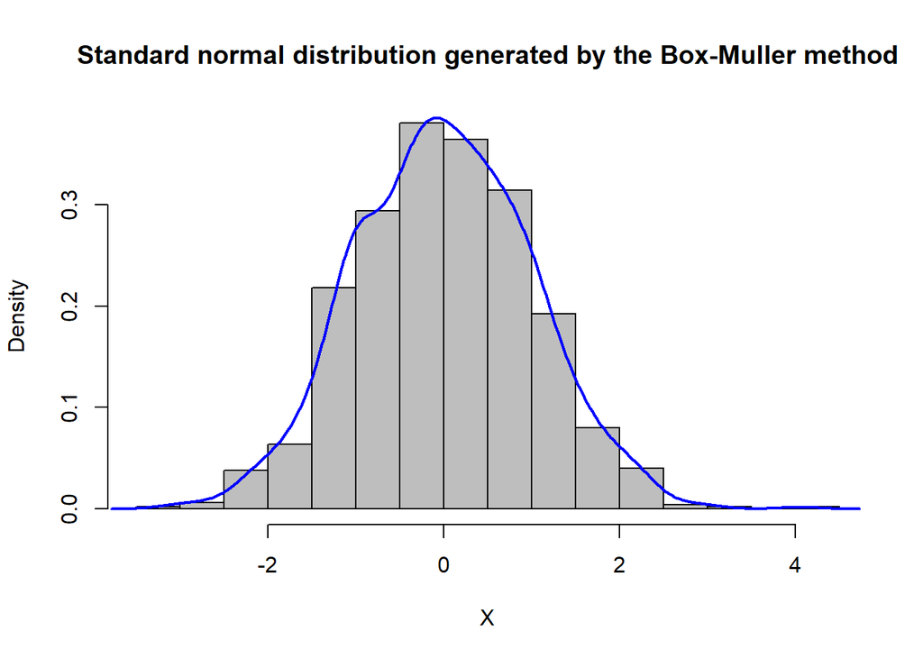

```
## [1] "Theoretical values:"
## [1] "Average:  0 , Median:  0"
## [1] "Variance:  1 , STD:  1"
## [1] "Generated values:"
## [1] "Average:  0.00366626831035658 , Median:  -0.00281213299092623"
## [1] "Variance:  0.994870400727495 , STD:  0.997431902802139"
```

```r
box <- normal_box(N=1000, mode="implemented")
plot_and_check_normal(box, title = "Standard normal distribution generated by the Box-Muller method")
```

## 2.7 Poisson distribution

Poisson distribution with mean $\theta >0$ is given by the formula
$$P(N=k) = e^{-{\theta}}\frac{\theta^k}{k!}, \quad k=1,2,3,...$$
We denote this by writing $N\sim Poisson(\theta)$. This is the distribution of the number of events in the interval $[0,1]$ when the times between each event are independent and have an exponential distribution with mean $1/\theta$. Then, a simple method of generating pseudorandom numbers from Poisson distribution is to generate exponential random variables $X_i = -log(U_i)/\theta$ from independent uniform distributions $U_i$, and then take $N$ as the largest integer for which $X_1 + .... + X_N \leq 1$. However, this method is rather slow, especially if $U_i$ is large. So there is an alternative method using the inverse transformation method. For discrete distributions, it amounts to a sequential search for the smallest $n$ in which $F(n) \leq U$, where $F$ denotes the distribution and $U\sim U[0,1]$. In the case of Poisson distribution, $F(n)$ is calculated as $P(N=0) + .... + P(N = n)$. Rather, instead of counting each individual expression, you can use the relation $P(N = k+1) = P(N=k)\theta / (k+1)$. The implementation of the algorithm is as follows.

```r
poisson <- function(N,theta,m=valid[1], a=valid[2], c=valid[3], x=valid[4], mode="self"){
  if ((check_assumptions(m,a,c) == 'Assumptions met!' & mode == "self") | mode != "self"){
    X <- c()
    i <- 0
    while(length(X) < N){
      p <- exp(-theta)
      Fd <- p
      Nbig <- 0

      i <- i+1
      if (mode == "self"){
        U <- lcgen(2,m,a,c,x+i)
      }else{
        U <- runif(2)
      }
      U1 <- U[2]
      while (U1 > Fd){
        Nbig <- Nbig + 1
        p <- p*theta/Nbig
        Fd <- Fd + p
        }
      X <- append(X,Nbig)
      }
    return(X)
    }else{
      print("Values for assumptions incorrect!")
      return(0)
    }
}
```

```r
plot_and_check_poiss <- function(X, theta,title){
  hist(X, prob=TRUE, col="grey", main=title)
  lines(density(X), col="blue", lwd=2)

  mean = theta
  median = (theta + 1/3 - 0.02/theta)
  var = theta
  std = 1

  mean_x = mean(X)
  median_x = median(X)
  var_x = var(X)
  std_x = sqrt(var_x)

  t <- c(mean, median, var, std)
  p <- c(mean_x, median_x, var_x, std_x)

  print("Theoretical values:")
  print(paste("Average: ", mean, ", Median: ", median))
  print(paste("Variance: ", var, ", STD: ", std))
  print("Generated values:")
  print(paste("Average: ", mean_x, ", Median: ", median_x))
  print(paste("Variance: ", var_x, ", STD: ", std_x))

  }
```

Now let’s check the generated values for $\theta =1$ and a sample of $N=1000$.

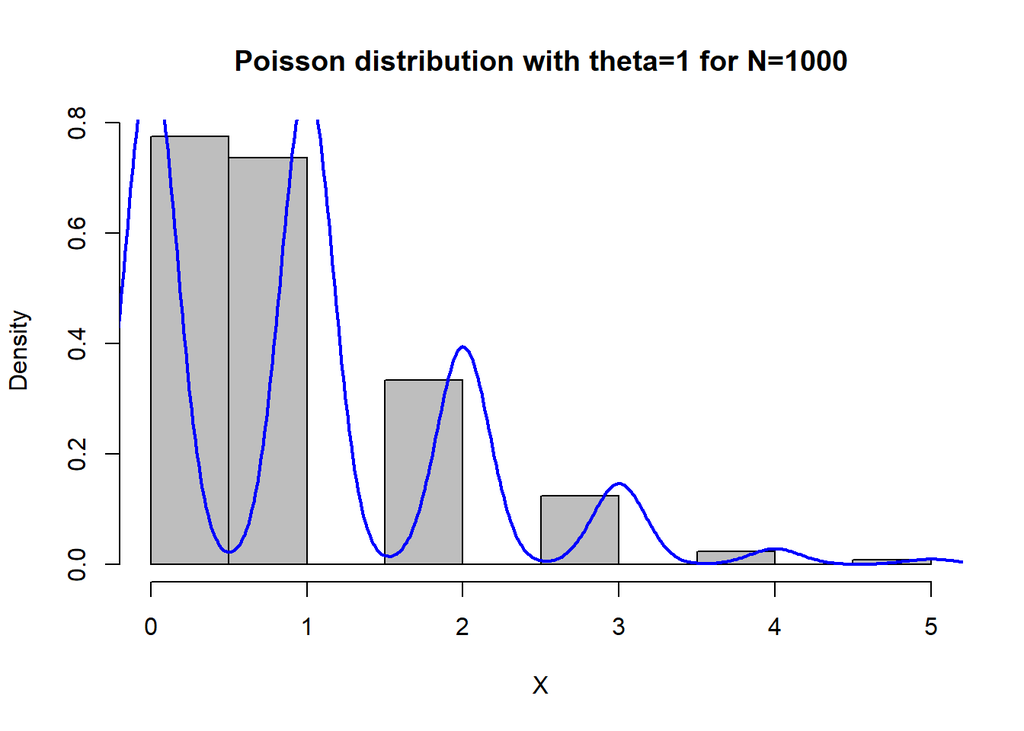

```
## [1] "Theoretical values:"
## [1] "Average:  1 , Median:  1.31333333333333"
## [1] "Variance:  1 , STD:  1"
## [1] "Generated values:"
## [1] "Average:  0.956 , Median:  1"
## [1] "Variance:  0.973037037037037 , STD:  0.986426397171648"
```

```r
pois <- poisson(N=1000,theta=1, mode="implemented")
plot_and_check_poiss(pois, theta=1, title = "Poisson distribution with theta=1 for N=1000")
```

The comparison of descriptive statistics from the sample and theoretical statistics looks very good. The values do not deviate too much from each other. The graph of the probability density function together with the histogram may look not very promising at first glance, but keep in mind that we are modeling here the number of events over a period of time. To be sure, let’s compare to a sample generated from an embedded generator.

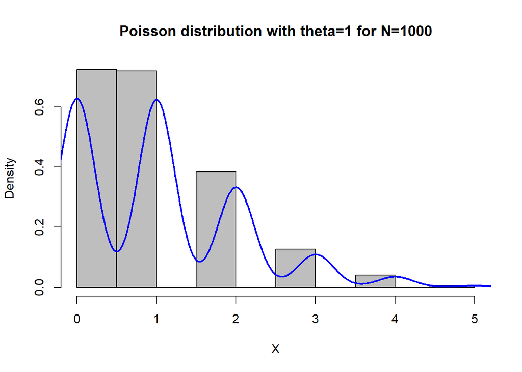

```
## [1] "Theoretical values:"
## [1] "Average:  1 , Median:  1.31333333333333"
## [1] "Variance:  1 , STD:  1"
## [1] "Generated values:"
## [1] "Average:  1.028 , Median:  1"
## [1] "Variance:  1.03425025025025 , STD:  1.01698094881382"
```

```r
pois <- rpois(1000,1)
plot_and_check_poiss(pois, theta=1, title = "Poisson distribution with theta=1 for N=1000")
```

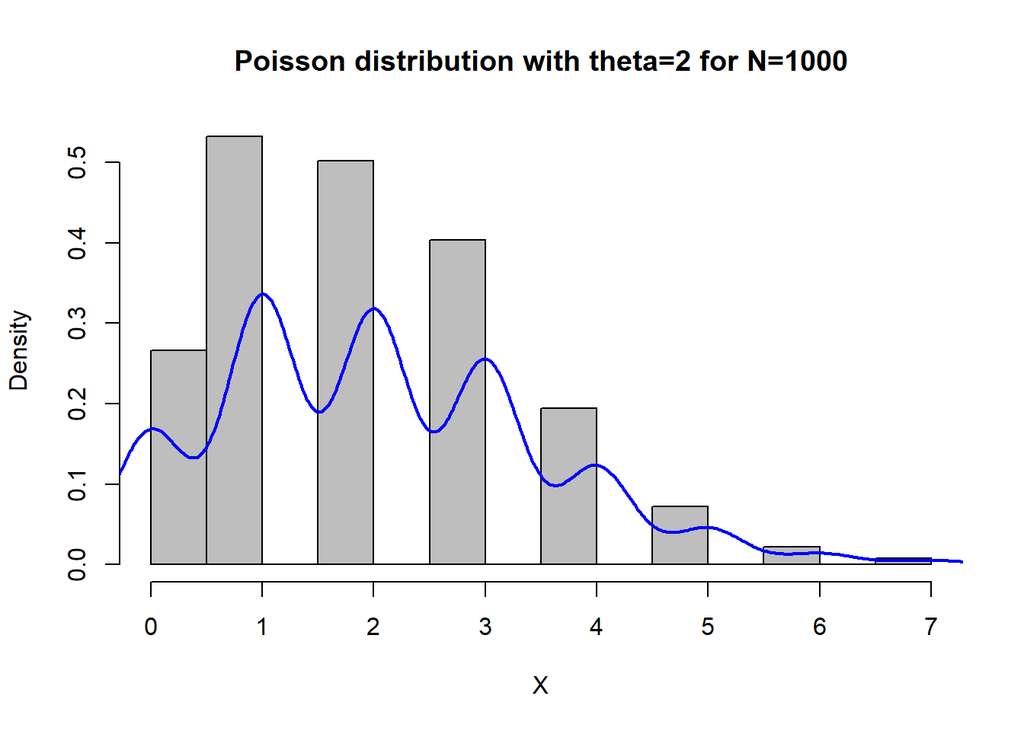

```
## [1] "Theoretical values:"
## [1] "Average:  2 , Median:  2.32333333333333"
## [1] "Variance:  2 , STD:  1"
## [1] "Generated values:"
## [1] "Average:  2.036 , Median:  2"
## [1] "Variance:  1.98869269269269 , STD:  1.41021015905173"
```

```r
pois <- poisson(N=1000,theta=2, mode="implemented")
plot_and_check_poiss(pois, theta=2, title = "Poisson distribution with theta=2 for N=1000")
```